# Assignment Part 1 -Song Bird Analysis

Sheena Davis

09/05/2021

This analysis was conducted in three part; the first part examined and compared the calls and songs of the European Robin while the second part compared the calls of European Robins with two other common garden birds.Finally, the third section compared the songs of European Robins with the songs of other members of the Subfamily *Erithacinae*.

## Script set up

To begin the necessary packages needed for this analysis were installed and the libraries were called.

```
necessary.packages<-c("devtools","behaviouR","tuneR","seewave","ggplot2","dplyr",
                      "warbleR","leaflet","lubridate","sp","sf","raster","mapview",
                      "leafem","BIRDS","xts","zoo", "stringr","vegan","rmarkdown","shiny")

already.installed <- necessary.packages%in%installed.packages()[,'Package'] #asks if the necessary packages are already installed
if (length(necessary.packages[!already.installed])>=1) { #if not installed download now
  install.packages(necessary.packages[!already.installed],dep=1)
}
sapply(necessary.packages, function(p){require(p,quietly = T,character.only = T)})
```

## Part 1

### Section 1

Part one analysed the calls and songs of the European Robin (*Erithacus rubecula*). Calls and songs were downloaded from xeno-canto and read into files prior to the analysis.

First the presence of recordings was checked for using the function query_xc() and stored as an object. The option ‘download = FALSE’ prevents the .MP3 records from being downloaded.

```
robin_song <-query_xc(qword = 'Erithacus rubecula cnt:"united kingdom" type:song len:5-25', download = FALSE)
robin_call<-query_xc(qword = 'Erithacus rubecula cnt:"united kingdom" type:call len:5-25', download = FALSE)
```

Next sub-folders were created in the RStudio Project for song calls and calls. Duplicates of each sound type were made as they would be used in multiple analyses.

```
dir.create(file.path("robin_song"))
dir.create(file.path("robin_song2"))
dir.create(file.path("robin_call"))
dir.create(file.path("robin_call2"))
```

For each folder the required .MP3 records were downloaded using the following line of code, substituting the relevant folder name with the desired sound name.

```
query_xc(X = robin_song, path="robin_song")
```

Using the *stringr* package, the structure of the names of the .MP3 files was changed using the code below. This allowed for more succinct file names. All 4 folders of robin files were changed using this code by simply substituting the folder name for each seperate folder.

```
old_files <- list.files("robin_song", full.names=TRUE)
new_files <- NULL
for(file in 1:length(old_files)){
  curr_file <- str_split(old_files[file], "-")
  new_name <- str_c(c(curr_file[[1]][1:2], "-song_", curr_file[[1]][3]), collapse="")
  new_files <- c(new_files, new_name)
}
file.rename(old_files, new_files)
```

Next the folders called robin_song and robin_call were copied into a new sub-folder entitled robin_audio. The duplicates of these files robin_call2 and robin_song2 will be used in a later analysis.

```
dir.create(file.path("robin_audio"))
file.copy(from=paste0("robin_song/",list.files("robin_song")),
          to="robin_audio")
file.copy(from=paste0("robin_call/",list.files("robin_call")),
          to="robin_audio")
```

Finally the .MP3 files were converted into .WAV files.The .MP3 files were then removed to save disk space. This was achieved using the following code:

```
mp32wav(path="robin_audio", dest.path="robin_audio")
unwanted_mp3 <- dir(path="robin_audio", pattern="*.mp3")
file.remove(paste0("robin_audio/", unwanted_mp3))
```

### Section 2

To visualize the differences in bird calls an oscillogram can be used.The difference between Robin alarm calls and songs can then be visualized,this is achieved using the oscillo() function.

```
robin_wav<- readWave("robin_audio/Erithacusrubecula-song_374144.wav")
robin_wav
oscillo(robin_wav)
```

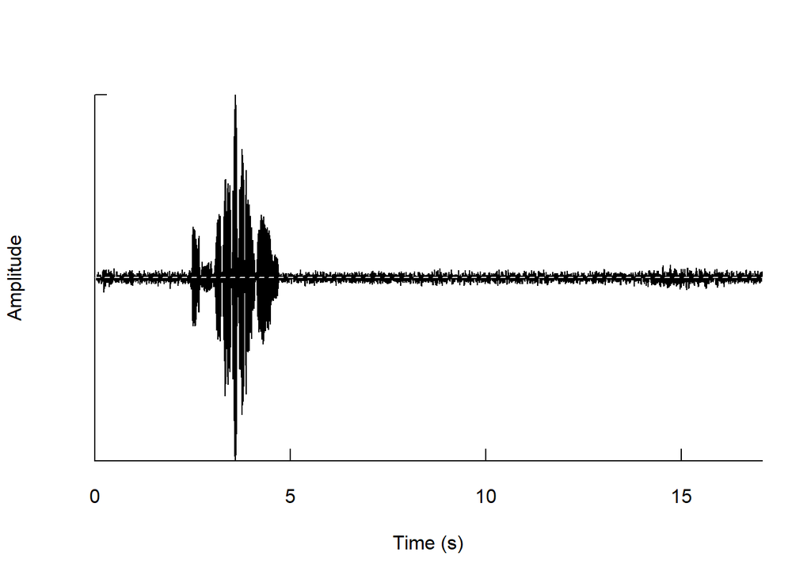

The wave can also be set for a specific time, for example; the plot below shows a small section of the wave from 0.59 to 0.60, which was achieved by the following code;

```
oscillo(robin_wav, from = 0.59, to = 0.60)
```

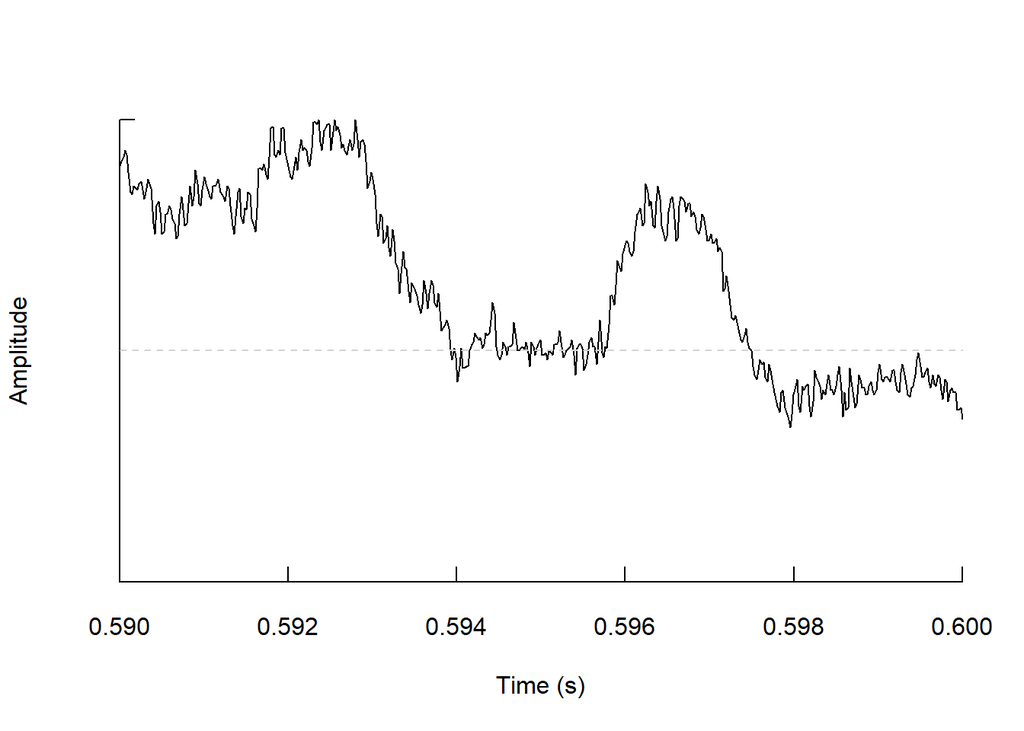

[output not shown]

Next the robin call recordings were visualised in the same way as the robin song recording above, this was to ascertain whether or not there is variation between the two sounds. The following two figures show the full sound wave of a robin call and a section of that same call from 0.59-0.60. Compared to the sound wave of the robin song shown above, it is clear that the two sounds differ greatly.

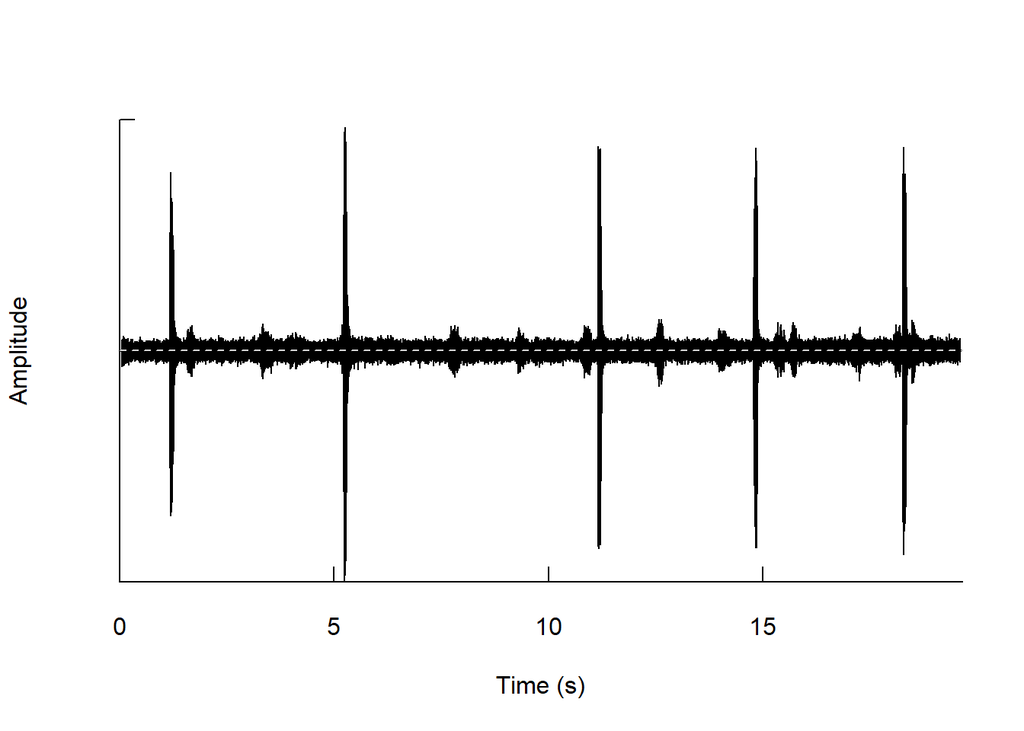

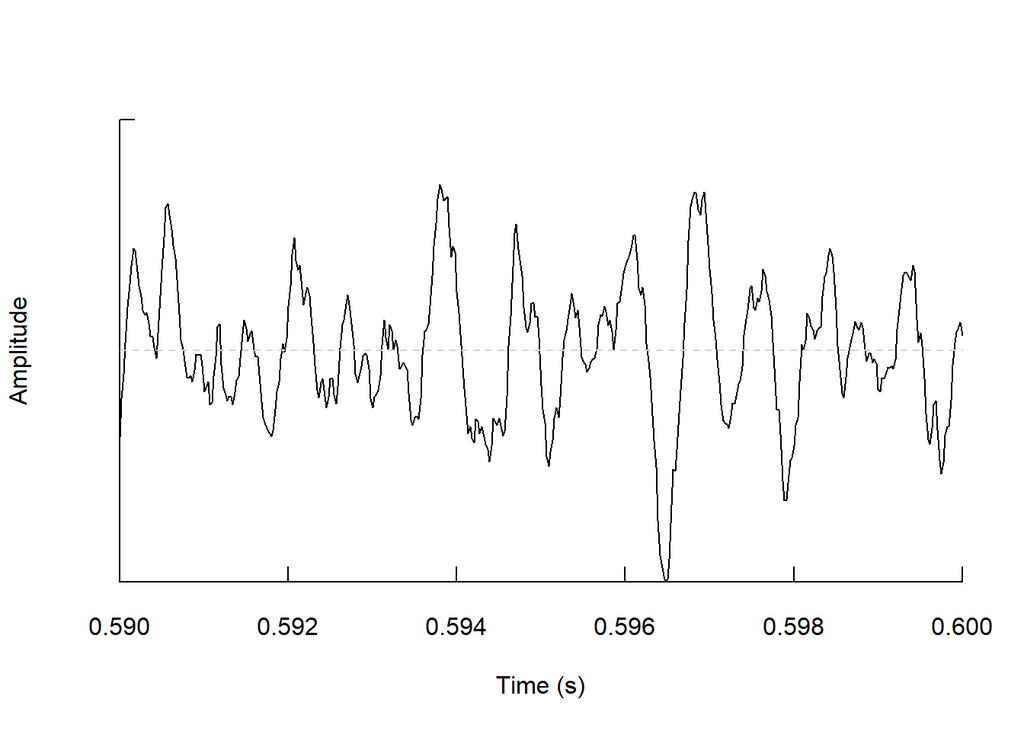

### Section 3

To further investigate the variation between the calls a principal component analysis (PCA) was carried out. Before the PCA was carried out the data was simplified by pushing it through Mel-frequency cepstral coefficients (MFCC), which identifies repeated patterns and extracts them to form a simplified data set that can be used in the PCA.An MFCC can be applied simply by using the MFCCfunction().

```
robin_mfcc <- MFCCFunction(input.dir = "robin_audio",
                               max.freq=7000)
```

To run the PCA, a source script nes8010.R with previously created functions necessary for the PCA was used.

```
robin_pca <- ordi_pca(robin_mfcc[, -1], scale=TRUE)
summary(robin_pca)

robin_sco <- ordi_scores(robin_pca, display="sites")
robin_sco <- mutate(robin_sco, group_code = robin_mfcc$Class)

ggplot(robin_sco, aes(x=PC1, y=PC2, colour=group_code)) +
  geom_point() +
  scale_colour_discrete(name = "Call Type",
                        labels = c("Red Breasted Robin call", "Red Breasted Robin song")) +
  theme_classic()
```

[output not shown]

[output cut: 69 more lines]

```
##
## Call:
## rda(X = spp_data, scale = TRUE)
##
## Partitioning of correlations:
##               Inertia Proportion
## Total             177          1
## Unconstrained     177          1
##
## Eigenvalues, and their contribution to the correlations
##
## Importance of components:
##                          PC1     PC2      PC3      PC4     PC5     PC6     PC7
## Eigenvalue            39.109 24.3534 16.24478 13.33151 7.71189 7.47134 6.11808
## Proportion Explained   0.221  0.1376  0.09178  0.07532 0.04357 0.04221 0.03457
## Cumulative Proportion  0.221  0.3585  0.45032  0.52564 0.56921 0.61143 0.64599
##                           PC8     PC9   PC10    PC11    PC12    PC13    PC14
## Eigenvalue            5.72414 4.82004 4.1772 3.95839 3.75520 3.51248 2.98929
## Proportion Explained  0.03234 0.02723 0.0236 0.02236 0.02122 0.01984 0.01689
## Cumulative Proportion 0.67833 0.70556 0.7292 0.75153 0.77274 0.79259 0.80947
##                          PC15    PC16    PC17    PC18    PC19    PC20     PC21
## Eigenvalue            2.83768 2.38678 2.27830 2.03720 1.87279 1.78660 1.741565
## Proportion Explained  0.01603 0.01348 0.01287 0.01151 0.01058 0.01009 0.009839
## Cumulative Proportion 0.82551 0.83899 0.85186 0.86337 0.87395 0.88405 0.893887
##                           PC22     PC23     PC24     PC25     PC26     PC27
## Eigenvalue            1.640379 1.373735 1.310667 1.226766 1.152533 0.976557
## Proportion Explained  0.009268 0.007761 0.007405 0.006931 0.006511 0.005517
## Cumulative Proportion 0.903155 0.910916 0.918321 0.925252 0.931763 0.937280
##                           PC28    PC29     PC30     PC31     PC32     PC33
## Eigenvalue            0.935212 0.83721 0.818550 0.761573 0.741273 0.654437
## Proportion Explained  0.005284 0.00473 0.004625 0.004303 0.004188 0.003697
## Cumulative Proportion 0.942564 0.94729 0.951919 0.956221 0.960409 0.964107
##                           PC34     PC35     PC36     PC37     PC38     PC39
## Eigenvalue            0.591877 0.545300 0.482408 0.436574 0.398149 0.381922
## Proportion Explained  0.003344 0.003081 0.002725 0.002467 0.002249 0.002158
## Cumulative Proportion 0.967451 0.970531 0.973257 0.975723 0.977973 0.980131
##                           PC40     PC41     PC42     PC43     PC44     PC45
## Eigenvalue            0.341514 0.298354 0.271363 0.255512 0.213056 0.198873
## Proportion Explained  0.001929 0.001686 0.001533 0.001444 0.001204 0.001124
## Cumulative Proportion 0.982060 0.983746 0.985279 0.986722 0.987926 0.989050
```

[output cut: 289 more lines]

[output not shown]

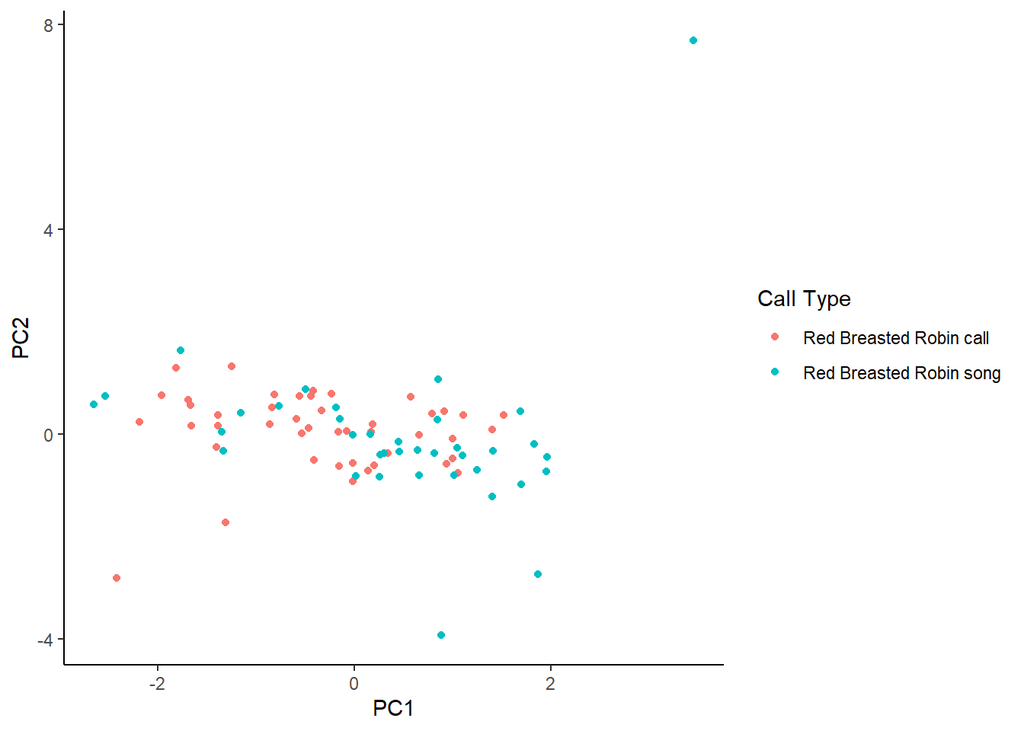

## Part 2

### Section 1

In Part 2 of the analysis, the robin call was then compared with the calls of two other common garden birds found in the United Kingdom, the house sparrow (*Passer domesticus*) and the coal tit (*Periparus ater*). Similarly to Part 1: Section 1,the calls of both these birds were downloaded, saved into appropriate folders and converted into .WAV files.

### Section 2

Using the oscillo() function, call waves of both these bird species were then visualised and compared to that of the robin call shown in Part 1.The following figures show the full call wave of a House sparrow and a small section of the call wave from 0.59-0.60.

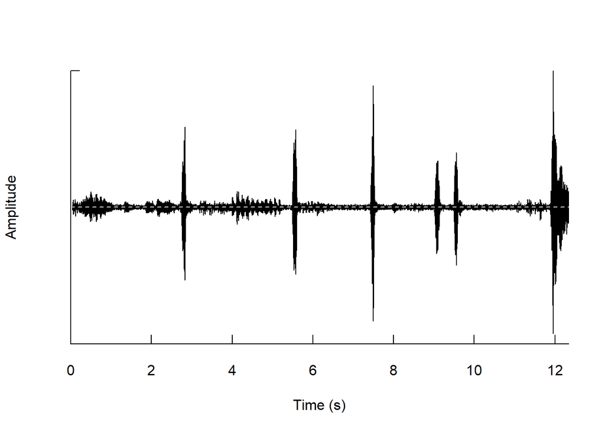

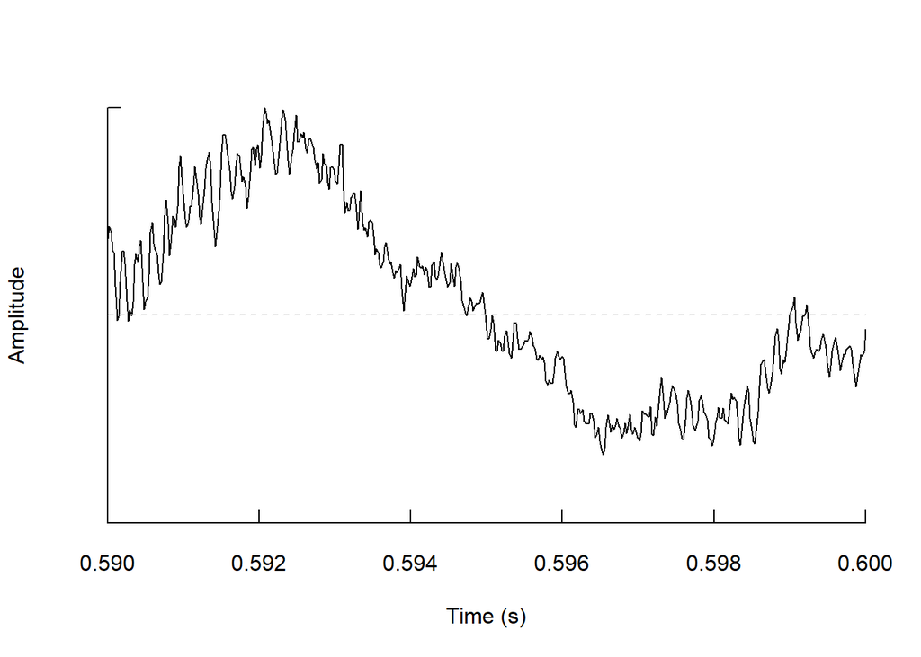

The following figures show the full call wave of a Coal Tit and a small section of the call wave from 0.59-0.60.

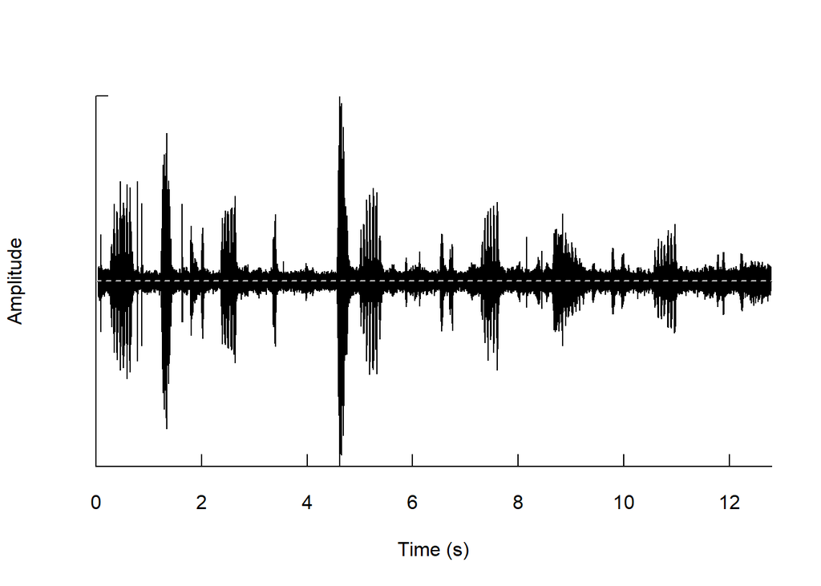

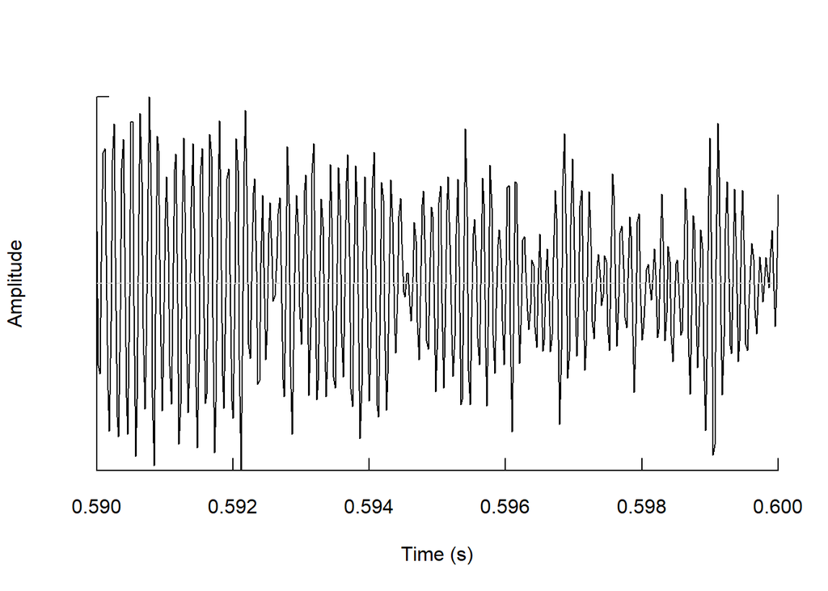

### Section 3

The data was then pushed through a MFCC and a PCA was subsequently run on the data, this was carried out in the same way as previously shown in Part 1: Section 3.

```
birds_mfcc <- MFCCFunction(input.dir = "birds_audio",
                           max.freq=7000)

birds_pca <- ordi_pca(birds_mfcc[, -1], scale=TRUE)
summary(birds_pca)

birds_sco <- ordi_scores(birds_pca, display="sites")
birds_sco <- mutate(birds_sco, group_code = birds_mfcc$Class)

ggplot(birds_sco, aes(x=PC1, y=PC2, colour=group_code)) +
  geom_point() +
  scale_colour_discrete(name = "Bird Type",
                      labels = c("Red Breasted Robin", "House Sparrow", "Coal Tit")) +
  theme_classic()
```

[output not shown]

[output cut: 104 more lines]

```
##
## Call:
## rda(X = spp_data, scale = TRUE)
##
## Partitioning of correlations:
##               Inertia Proportion
## Total             177          1
## Unconstrained     177          1
##
## Eigenvalues, and their contribution to the correlations
##
## Importance of components:
##                          PC1     PC2      PC3     PC4     PC5     PC6     PC7
## Eigenvalue            45.304 23.9208 16.05607 12.4423 8.43860 7.51556 5.72140
## Proportion Explained   0.256  0.1351  0.09071  0.0703 0.04768 0.04246 0.03232
## Cumulative Proportion  0.256  0.3911  0.48181  0.5521 0.59978 0.64224 0.67457
##                           PC8     PC9    PC10    PC11   PC12    PC13    PC14
## Eigenvalue            4.61729 4.44929 3.83247 3.32484 2.9550 2.80275 2.53873
## Proportion Explained  0.02609 0.02514 0.02165 0.01878 0.0167 0.01583 0.01434
## Cumulative Proportion 0.70066 0.72579 0.74744 0.76623 0.7829 0.79876 0.81310
##                          PC15    PC16    PC17     PC18     PC19     PC20
## Eigenvalue            2.05441 1.88450 1.82086 1.704756 1.623821 1.582792
## Proportion Explained  0.01161 0.01065 0.01029 0.009631 0.009174 0.008942
## Cumulative Proportion 0.82471 0.83536 0.84564 0.855275 0.864449 0.873391
##                           PC21     PC22     PC23     PC24     PC25     PC26
## Eigenvalue            1.499020 1.322018 1.244414 1.157758 1.110382 1.027998
## Proportion Explained  0.008469 0.007469 0.007031 0.006541 0.006273 0.005808
## Cumulative Proportion 0.881860 0.889329 0.896360 0.902901 0.909174 0.914982
##                           PC27     PC28     PC29     PC30     PC31     PC32
## Eigenvalue            1.002038 0.874000 0.852894 0.809948 0.727595 0.701015
## Proportion Explained  0.005661 0.004938 0.004819 0.004576 0.004111 0.003961
## Cumulative Proportion 0.920643 0.925581 0.930400 0.934976 0.939086 0.943047
##                           PC33    PC34     PC35     PC36    PC37     PC38
## Eigenvalue            0.656159 0.62134 0.594527 0.560530 0.52395 0.494751
## Proportion Explained  0.003707 0.00351 0.003359 0.003167 0.00296 0.002795
## Cumulative Proportion 0.946754 0.95026 0.953623 0.956790 0.95975 0.962545
##                           PC39     PC40     PC41     PC42     PC43     PC44
## Eigenvalue            0.469155 0.439997 0.395449 0.379685 0.353485 0.329743
## Proportion Explained  0.002651 0.002486 0.002234 0.002145 0.001997 0.001863
## Cumulative Proportion 0.965196 0.967682 0.969916 0.972061 0.974058 0.975921
```

[output cut: 340 more lines]

[output not shown]

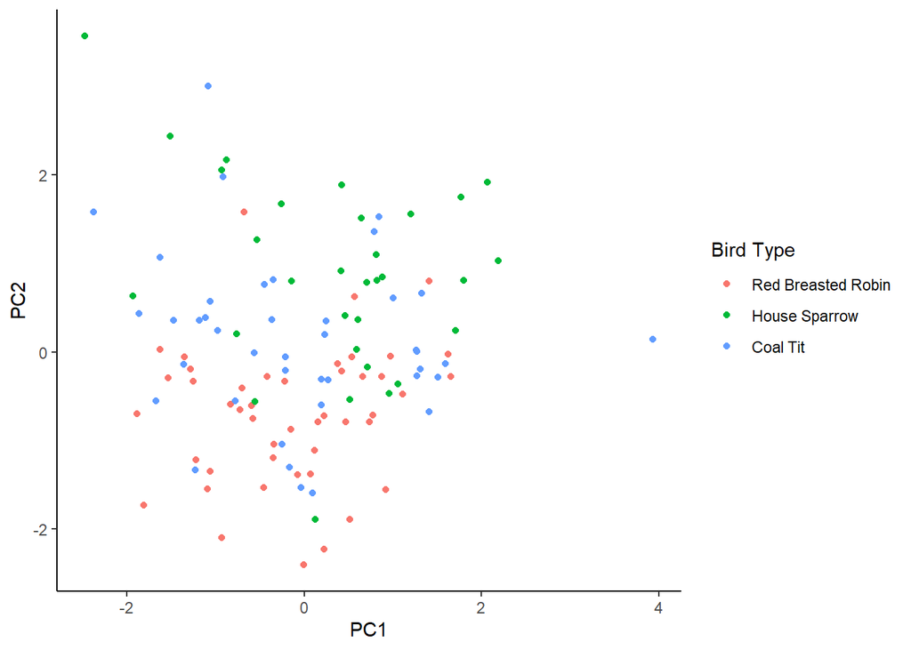

## Part 3

### Section 1

Out of interest, this section explores the variation in the songs of Old World Flycatchers, focusing on the Subfamily *Erithacinae*. This analysis included the European Robin, the Cape Robin-chat (*Cossypha caffra*), the Spotted Palm Thrush (*Cichladusa guttata*) and the Forest Robin (*Stiphrornis erythrothorax*). While the European Robin is found in the United Kingdoom, the other 3 species are found in various African countries such as South Africa, Kenya and areas of Central Africa. Similarly to Part 1: Section 1,the songs of these birds were downloaded, saved into appropriate folders and converted into .WAV files.

### Section 2

Using the oscillo() function, call waves of these bird species were then visualised and compared to that of the robin call shown in Part 1. The following figures show the full call wave of a Cape Robin-chat and a small section of the call wave from 0.59-0.60.

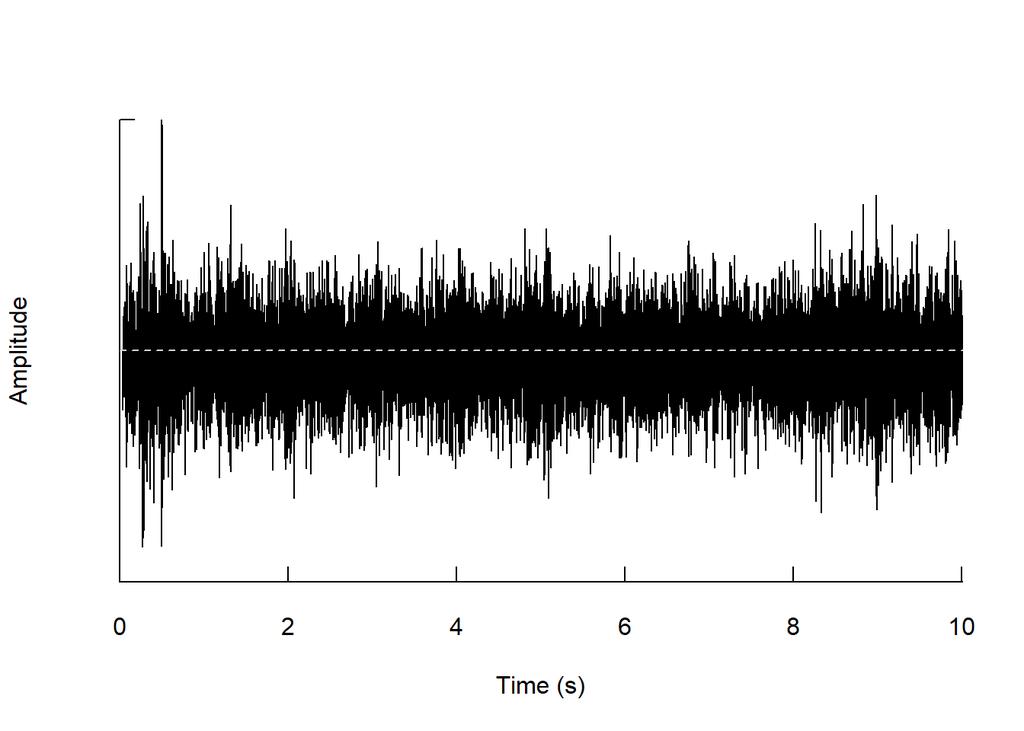

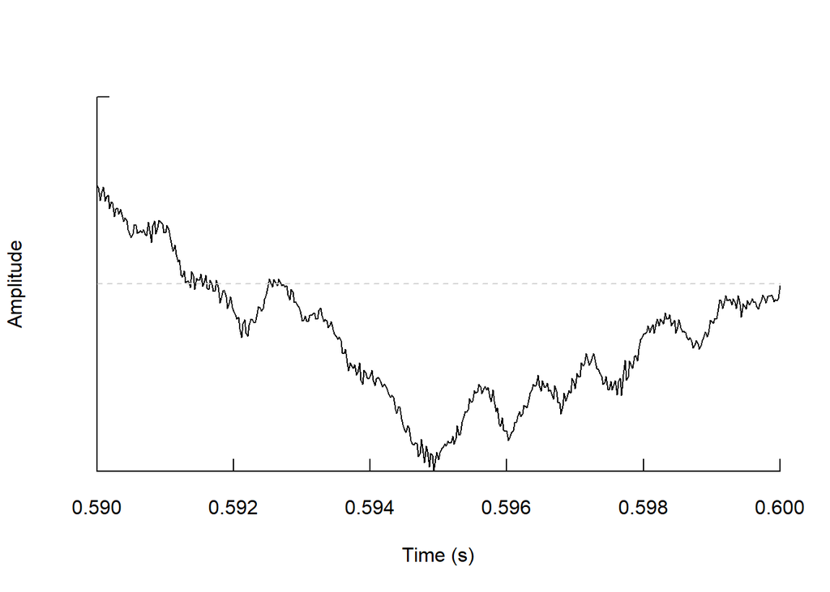

The following figures show the full call wave of a Spotted Palm Thrush and a small section of the call wave from 0.59-0.60.

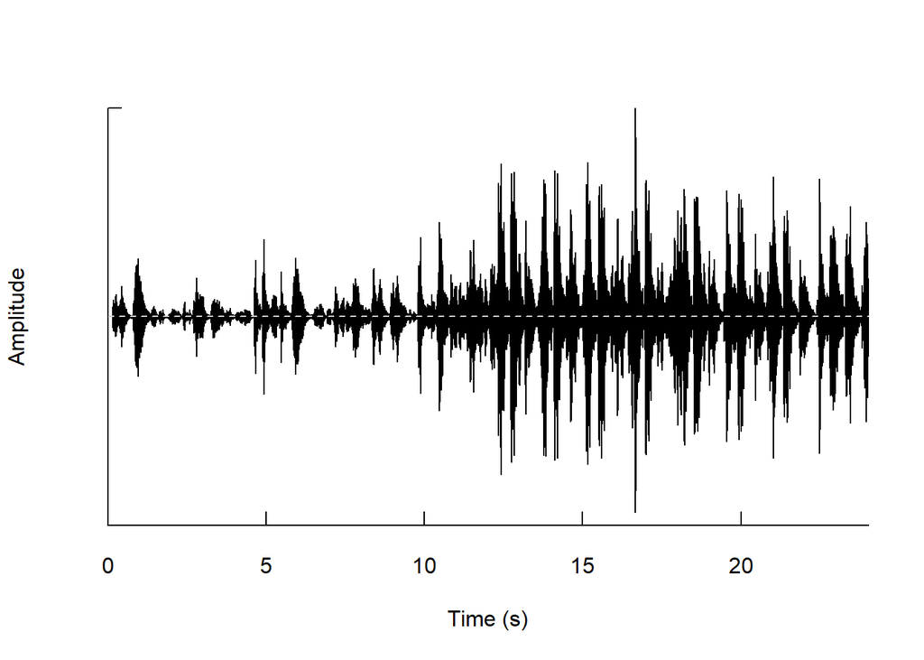

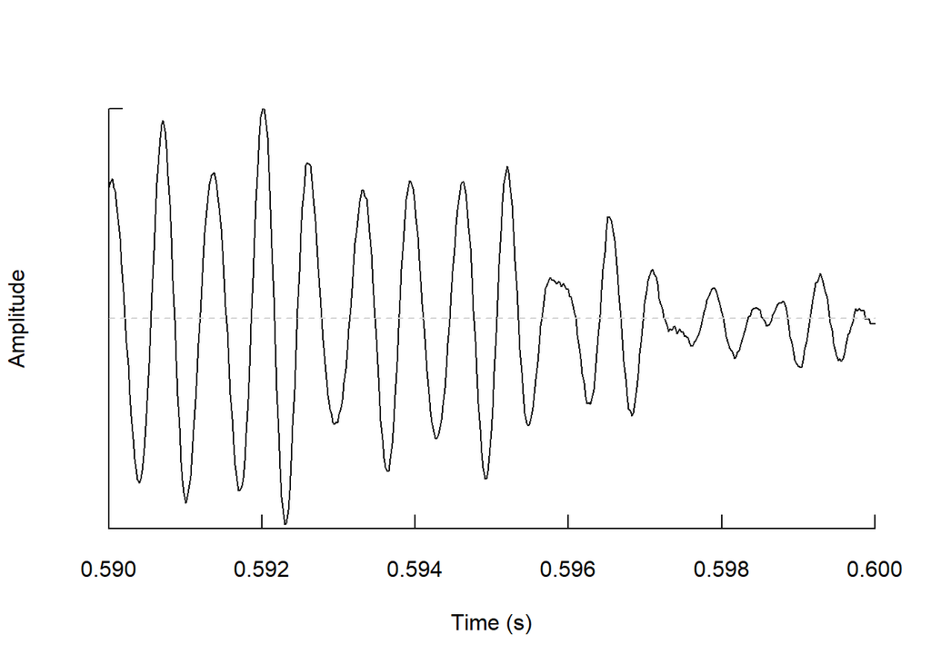

The following figures show the full call wave of a Forest Robin and a small section of the call wave from 0.59-0.60.

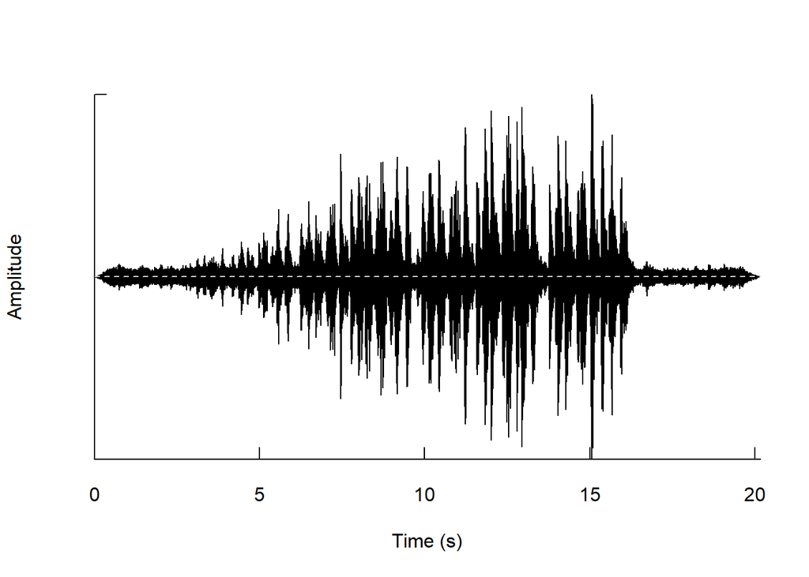

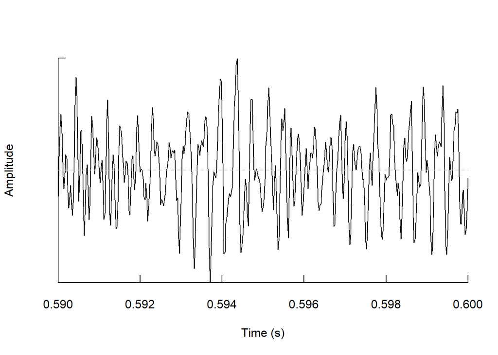

### Section 3

The data was then pushed through a MFCC and a PCA was subsequently run on the data, this was carried out in the same way as previously shown in Part 1: Section 3.

```
erithacinae_mfcc <- MFCCFunction(input.dir = "erithacinae_audio",
                           max.freq=7000)
dim(erithacinae_mfcc)

erithacinae_pca <- ordi_pca(erithacinae_mfcc[, -1], scale=TRUE)
summary(erithacinae_pca)

erith_sco <- ordi_scores(erithacinae_pca, display="sites")
erith_sco <- mutate(erith_sco, group_code = erithacinae_mfcc$Class)

ggplot(erith_sco, aes(x=PC1, y=PC2, colour=group_code)) +
  geom_point() +
  scale_colour_discrete(name = "Bird Type",
                        labels = c("Spotted Palm Thrush", "Cape Robin-chat", "Red Breasted Robin", "Forest Robin")) +
  theme_classic()
```

[output not shown]

[output cut: 90 more lines]

```
## [1] 105 178
```

```
##
## Call:
## rda(X = spp_data, scale = TRUE)
##
## Partitioning of correlations:
##               Inertia Proportion
## Total             177          1
## Unconstrained     177          1
##
## Eigenvalues, and their contribution to the correlations
##
## Importance of components:
##                           PC1     PC2     PC3      PC4     PC5     PC6     PC7
## Eigenvalue            34.6658 22.5435 17.3985 10.58065 9.40758 6.93596 5.88817
## Proportion Explained   0.1959  0.1274  0.0983  0.05978 0.05315 0.03919 0.03327
## Cumulative Proportion  0.1959  0.3232  0.4215  0.48129 0.53444 0.57363 0.60689
##                           PC8     PC9    PC10    PC11    PC12   PC13    PC14
## Eigenvalue            5.56656 5.25026 4.21767 3.95628 3.83484 3.3098 2.77281
## Proportion Explained  0.03145 0.02966 0.02383 0.02235 0.02167 0.0187 0.01567
## Cumulative Proportion 0.63834 0.66801 0.69183 0.71419 0.73585 0.7546 0.77022
##                          PC15    PC16    PC17    PC18    PC19    PC20    PC21
## Eigenvalue            2.66343 2.51429 2.29970 2.12005 2.03283 1.86304 1.80196
## Proportion Explained  0.01505 0.01421 0.01299 0.01198 0.01148 0.01053 0.01018
## Cumulative Proportion 0.78526 0.79947 0.81246 0.82444 0.83592 0.84645 0.85663
##                           PC22     PC23     PC24     PC25     PC26     PC27
## Eigenvalue            1.674751 1.503806 1.419632 1.380959 1.366155 1.264384
## Proportion Explained  0.009462 0.008496 0.008021 0.007802 0.007718 0.007143
## Cumulative Proportion 0.866093 0.874589 0.882609 0.890411 0.898130 0.905273
##                           PC28     PC29   PC30     PC31     PC32     PC33
## Eigenvalue            1.174464 1.039677 1.0089 0.985527 0.907444 0.829191
## Proportion Explained  0.006635 0.005874 0.0057 0.005568 0.005127 0.004685
## Cumulative Proportion 0.911908 0.917782 0.9235 0.929050 0.934177 0.938862
##                           PC34     PC35     PC36     PC37     PC38     PC39
## Eigenvalue            0.802619 0.771004 0.739490 0.662552 0.622895 0.576456
## Proportion Explained  0.004535 0.004356 0.004178 0.003743 0.003519 0.003257
## Cumulative Proportion 0.943396 0.947752 0.951930 0.955673 0.959193 0.962449
##                           PC40     PC41     PC42     PC43     PC44     PC45
## Eigenvalue            0.466336 0.452269 0.445202 0.409443 0.389669 0.341876
## Proportion Explained  0.002635 0.002555 0.002515 0.002313 0.002202 0.001932
## Cumulative Proportion 0.965084 0.967639 0.970154 0.972468 0.974669 0.976601
```

[output cut: 322 more lines]

[output not shown]

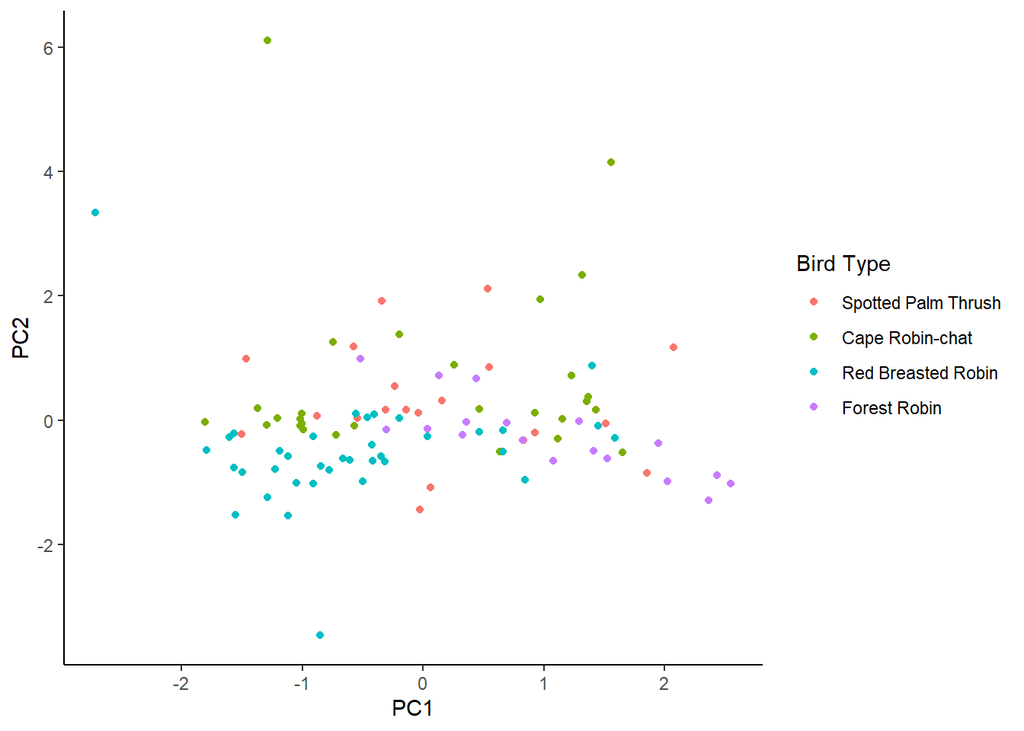